# COVID-19 JH Analysis

Sam Lausten

2023-04-26

## Introduction

The COVID-19 pandemic has been a major health crisis worldwide, affecting millions of people and causing significant economic, social, and psychological consequences. The pandemic is caused by the SARS-CoV-2 virus, which was first identified in Wuhan, China in December 2019. Since then, the virus has spread rapidly across the world, leading to numerous deaths and hospitalizations. In this project, we will import, tidy, and analyze the COVID19 dataset from the Johns Hopkins Github site. We will also perform some visualizations and modeling to gain insights into the data.

```r
# Importing necessary libraries
library(dplyr)
library(tidyverse)
```

```r
library(ggplot2)
library(lubridate)
```

## Data Import and Tidying

We will begin by importing the necessary libraries and loading the COVID19 dataset.

```
## # A tibble: 6 × 6
##   Province.State Country.Region   Lat  Long date       cases
##   <chr>          <chr>          <dbl> <dbl> <date>     <int>
## 1 ""             Afghanistan     33.9  67.7 2020-02-24     5
## 2 ""             Afghanistan     33.9  67.7 2020-02-25     5
## 3 ""             Afghanistan     33.9  67.7 2020-02-26     5
## 4 ""             Afghanistan     33.9  67.7 2020-02-27     5
## 5 ""             Afghanistan     33.9  67.7 2020-02-28     5
## 6 ""             Afghanistan     33.9  67.7 2020-02-29     5
```

## Data Anlysis

Let’s first take a look at the total number of Daily cases per day and also the top 15 countries that contributed to this dataset.

```r
# Grouping the data by country
covid_data_by_country <- covid_data_tidy %>%
  group_by(Country.Region, date) %>%
  summarise(total_cases = sum(cases)) %>%
  ungroup()
```

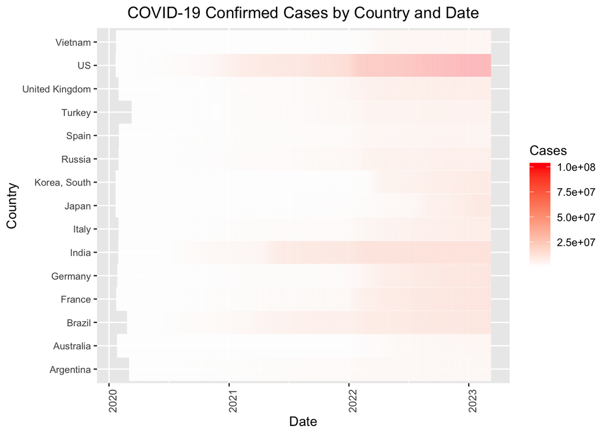

```r
# Grouping the data by date
covid_data_by_date <- covid_data_tidy %>%
  group_by(date) %>%
  summarise(total_cases = sum(cases)) %>%
  ungroup() %>%
  mutate(daily_cases = c(total_cases[1], diff(total_cases)))

# Filter the top 15 countries by total cases
top_15_countries <- covid_data_by_country %>%
  filter(date == max(date)) %>%
  arrange(desc(total_cases)) %>%
  slice(1:15) %>%
  pull(Country.Region)

# Filter the data to only include the top 15 countries
covid_data_top_15 <- covid_data_by_country %>%
  filter(Country.Region %in% top_15_countries)

# Create the heatmap
ggplot(covid_data_top_15, aes(x = date, y = Country.Region, fill = total_cases)) +
  geom_tile(color = "white") +
  scale_fill_gradient(low = "white", high = "red") +
  labs(title = "COVID-19 Confirmed Cases by Country and Date",
       x = "Date",
       y = "Country",
       fill = "Cases") +
  theme(axis.text.x = element_text(angle = 90, hjust = 1),
        axis.text.y = element_text(size = 8),
        plot.title = element_text(hjust = 0.5))
```

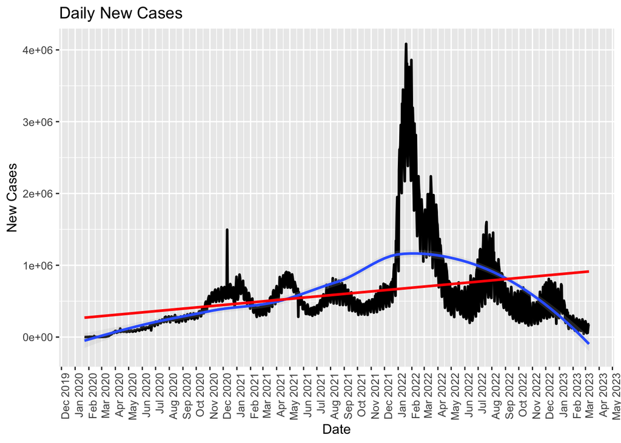

```r
# Fit a linear regression model to the daily new cases data
model <- lm(daily_cases ~ as.numeric(date), data = covid_data_by_date)

# Plot the daily new cases with a smooth best-fit line and a linear regression line
ggplot(covid_data_by_date, aes(x = date, y = daily_cases)) +
  geom_line(linewidth = 1) +
  stat_smooth(method = "loess", se = TRUE, fill = "grey", alpha = 0.2) +
  geom_smooth(method = "lm", se = FALSE, color = "red") +
  scale_x_date(date_breaks = "1 month", date_labels = "%b %Y") +
  labs(title = "Daily New Cases",
       x = "Date",
       y = "New Cases") +
  theme(axis.text.x = element_text(angle = 90, hjust = 1))
```